# Analysis Walkthrough

Author

Marisol Cabrera

### First load in the libraries needed

Load the libraries: tidyverse, nycflights13, tigris, tidycensus, tmap, tmaptools, janitor, writexl, here

### Functions

Now we are going to create a function that will return the sum of 2 numbers. Then we’ll run an example of the function.

```r
#naming this function "summun" we want the function to run on two arguments, "x" and "y" which will be the two numbers we want to add together
sumnum <- function(x, y) {
  #the function will perform the simple arithmetic function as coded here
  result <- x+y
    #we want to make sure the result is actually displayed in the end so we      will make sure to include a return line
    return(result)
  }

#Here is the function in action
sumnum(2,3)
```

```
[1] 5
```

Now lets create a function that will return the mean of a list of numbers fed to it.

```r
#the argument for this function will be a list of numbers so we will label the argument as "mean_vector"
mean_function <- function(mean_vector){
  #this function mean to find the mean so we can use the "mean" function to perform this task
  result <- mean(mean_vector)
  #In order to spit out a result at the end of the function we need to include this "result" line
  return(result)
}

#Here is the function in action with a set of numbers
mean_function(c(1,2,3))
```

```
[1] 2
```

Next, we are adding on to the above function to have it return the results in the form of the sentence “The mean is ___” where the blank is the mean.

```r
#Now we are adding a print factor
mean_function_print <- function(mean_vector){
  #Here we want the result object to include this "paste0" function in addition to the "mean" function. We can have the text always start off with "The mean is " making sure to add a space at the end and have the sentence end with what ever mean value to function calculates.
  result <- paste0("The mean is ", mean(mean_vector))
  #again make sure to include the return line to display a result
  return(result)
}

#here is the funciton in action
mean_function_print(c(1,2,3))
```

```
[1] "The mean is 2"
```

We will now switch up the dataset used. To download this “flights” data set we need to make sure to have the “nycflights13” package installed. Lets run all of this.

```r
#load the data to use for the rest of the assignment questions
flights <- nycflights13::flights
```

Here’s the data:

```r
#using the head function gives us the first 6 rows of the data set to get a feel for the data format
head(flights)
```

```
# A tibble: 6 × 19
   year month   day dep_time sched_dep…¹ dep_d…² arr_t…³ sched…⁴ arr_d…⁵ carrier
  <int> <int> <int>    <int>       <int>   <dbl>   <int>   <int>   <dbl> <chr>
1  2013     1     1      517         515       2     830     819      11 UA
2  2013     1     1      533         529       4     850     830      20 UA
3  2013     1     1      542         540       2     923     850      33 AA
4  2013     1     1      544         545      -1    1004    1022     -18 B6
5  2013     1     1      554         600      -6     812     837     -25 DL
6  2013     1     1      554         558      -4     740     728      12 UA
# … with 9 more variables: flight <int>, tailnum <chr>, origin <chr>,
#   dest <chr>, air_time <dbl>, distance <dbl>, hour <dbl>, minute <dbl>,
#   time_hour <dttm>, and abbreviated variable names ¹sched_dep_time,
#   ²dep_delay, ³arr_time, ⁴sched_arr_time, ⁵arr_delay
```

This data includes records of individual airline flights departing at New York’s three metro airports, JFK, LaGuardia (LGA) and Newark (EWR).

Now, we will create a function that filters the data frame to only include records from a single originating airport.

```r
#This function's argument will be the abbreviation of the airport name
filter_airport <- function(airport){
  #using the filter function with the airport abbreviation will return information for only the airport selected
  result <- filter(flights, origin == airport)
  #make sure to include the return line to display a result
  return(result)
}

#example of function
filter_airport("EWR")
```

```
# A tibble: 120,835 × 19
    year month   day dep_time sched_de…¹ dep_d…² arr_t…³ sched…⁴ arr_d…⁵ carrier
   <int> <int> <int>    <int>      <int>   <dbl>   <int>   <int>   <dbl> <chr>
 1  2013     1     1      517        515       2     830     819      11 UA
 2  2013     1     1      554        558      -4     740     728      12 UA
 3  2013     1     1      555        600      -5     913     854      19 B6
 4  2013     1     1      558        600      -2     923     937     -14 UA
 5  2013     1     1      559        600      -1     854     902      -8 UA
 6  2013     1     1      601        600       1     844     850      -6 B6
 7  2013     1     1      606        610      -4     858     910     -12 AA
 8  2013     1     1      607        607       0     858     915     -17 UA
 9  2013     1     1      608        600       8     807     735      32 MQ
10  2013     1     1      615        615       0     833     842      -9 DL
# … with 120,825 more rows, 9 more variables: flight <int>, tailnum <chr>,
#   origin <chr>, dest <chr>, air_time <dbl>, distance <dbl>, hour <dbl>,
#   minute <dbl>, time_hour <dttm>, and abbreviated variable names
#   ¹sched_dep_time, ²dep_delay, ³arr_time, ⁴sched_arr_time, ⁵arr_delay
```

Next, we will create a function that filters the data frame to only include records from a single originating airport and aggregates the results by airlines to show how many flights each airline has from that airport.

```r
#This function will build off our previous function, again the argument remains the same, the airport abbreviation
new_filter_airport <- function(airport){
  #filter function information remains the same
  flight_data_set <- filter(flights, origin == airport)
  #the result will change slights to select only the data we want displayed, the carrier, and the count of this value in the other column
  result <- flight_data_set %>%
    group_by(carrier) %>%
    summarise(count=n())
  #Include this line so result is actually displayed
  return(result)
}

#Example of function in action
new_filter_airport("LGA")
```

```
# A tibble: 13 × 2
   carrier count
   <chr>   <int>
 1 9E       2541
 2 AA      15459
 3 B6       6002
 4 DL      23067
 5 EV       8826
 6 F9        685
 7 FL       3260
 8 MQ      16928
 9 OO         26
10 UA       8044
11 US      13136
12 WN       6087
13 YV        601
```

# Census Data

Now we will look at census data. The following sections will require use of the tidycensus package, so make sure that is downloaded. Additionally, we will be downloading the data on populations with bachelor’s and graduate/professional degrees.

### Credentials

First make sure your API Key credential is loaded. You only have to do this once so download here: https://api.census.gov/data/key_signup.html

Then after it is downloaded once, comment the following line so you’re code runs correctly.

```r
#census_api_key("d0f1c94dadbeb7b2428ea94375fe77ec92f5411f", install=TRUE)
```

Here are the census variables we will be using:

```r
myvars <- c(education_total = "B06009_001",
            education_bachelors = "B06009_005",
            education_gradprofess = "B06009_006")
```

Now, lets pull down the state-level data for these variables.

```r
#To do this we will use the "get_acs" function that is a part of the tidycensus package. Since we want the state level, we will make sure geography = "state" and we will make sure geometry = TRUE to pull down the geospatial/mapping data tied to each state
get_acs(geography = "state",
        variables = myvars,
        output = "wide",
        geometry = TRUE)
```

```
Downloading feature geometry from the Census website.  To cache shapefiles for use in future sessions, set `options(tigris_use_cache = TRUE)`.
```

```
Simple feature collection with 52 features and 8 fields
Geometry type: MULTIPOLYGON
Dimension:     XY
Bounding box:  xmin: -179.1489 ymin: 17.88328 xmax: 179.7785 ymax: 71.36516
Geodetic CRS:  NAD83
First 10 features:
   GEOID        NAME education_totalE education_totalM education_bachelorsE
1     35  New Mexico          1415298              944               223875
2     72 Puerto Rico               NA               NA                   NA
3     06  California         26665143             1135              5764827
4     01     Alabama          3344006             1279               546674
5     13     Georgia          6996425             2142              1377311
6     05    Arkansas          2026722             1113               308648
7     41      Oregon          2944830              938               627360
8     28 Mississippi          1983112             1576               274566
```

[output cut: 24 more lines]

Let’s clean up the data set, removing the three “margin of error” columns

```r
#to do this we will name and save the data set created with the "get_acs" function
allstates_wide <- get_acs(geography = "state",
        variables = myvars,
        output = "wide",
        geometry = TRUE)
```

```
Downloading feature geometry from the Census website.  To cache shapefiles for use in future sessions, set `options(tigris_use_cache = TRUE)`.
```

```r
#now lets create a new data set called "clean_allstates_wide" that is cleaned up using the "select" function removing, using the "-" character, all columns that end with "m" as that denotes the margin of error columns
clean_allstates_wide <- allstates_wide %>%
  select(-ends_with("M"))

#here is the new clean data set
clean_allstates_wide
```

```
Simple feature collection with 52 features and 5 fields
Geometry type: MULTIPOLYGON
Dimension:     XY
Bounding box:  xmin: -179.1489 ymin: 17.88328 xmax: 179.7785 ymax: 71.36516
Geodetic CRS:  NAD83
First 10 features:
   GEOID        NAME education_totalE education_bachelorsE
1     35  New Mexico          1415298               223875
2     72 Puerto Rico               NA                   NA
3     06  California         26665143              5764827
4     01     Alabama          3344006               546674
5     13     Georgia          6996425              1377311
6     05    Arkansas          2026722               308648
7     41      Oregon          2944830               627360
8     28 Mississippi          1983112               274566
9     08    Colorado          3900754              1015989
10    49        Utah          1868472               429936
   education_gradprofessE                       geometry
1                  174413 MULTIPOLYGON (((-109.0502 3...
2                      NA MULTIPOLYGON (((-65.23805 1...
3                 3492046 MULTIPOLYGON (((-118.6044 3...
4                  330370 MULTIPOLYGON (((-88.05338 3...
5                  875351 MULTIPOLYGON (((-81.27939 3...
6                  174047 MULTIPOLYGON (((-94.61792 3...
7                  385684 MULTIPOLYGON (((-123.6647 4...
8                  176633 MULTIPOLYGON (((-88.50297 3...
9                  606864 MULTIPOLYGON (((-109.0603 3...
10                 218134 MULTIPOLYGON (((-114.053 37...
```

Now we will create a new column that contains the percentage of people with a bachelor’s or higher degree for each state.

```r
#Since the Census counts people with a bachelor's only vs. a graduate degree separately, we will need to combine the two categories before making our calculation against the total population column. To do this we will use the mutate function to combine "education_bachelorsE" and "education_gradprofessE"
new_clean_allstates_wide <- clean_allstates_wide %>%
  mutate(bach_or_higher = education_bachelorsE + education_gradprofessE)

#With that new combined column created we can use the mutate function again to create the percentage column
pctdata_new_clean_allstates_wide <- new_clean_allstates_wide %>%
  mutate(pct_ed_bach_or_higher = (bach_or_higher / education_totalE) *100)

#here is the data set with out new columns
pctdata_new_clean_allstates_wide
```

```
Simple feature collection with 52 features and 7 fields
Geometry type: MULTIPOLYGON
Dimension:     XY
Bounding box:  xmin: -179.1489 ymin: 17.88328 xmax: 179.7785 ymax: 71.36516
Geodetic CRS:  NAD83
First 10 features:
   GEOID        NAME education_totalE education_bachelorsE
1     35  New Mexico          1415298               223875
2     72 Puerto Rico               NA                   NA
3     06  California         26665143              5764827
4     01     Alabama          3344006               546674
5     13     Georgia          6996425              1377311
6     05    Arkansas          2026722               308648
7     41      Oregon          2944830               627360
8     28 Mississippi          1983112               274566
```

[output cut: 24 more lines]

Now let’s create a map of the continental U.S. showing the new percentage measure we’ve created.

```r
#First we need to use the filter function to filter out Alaska, Hawaii and Puerto Rico
NEW_pctdata_new_clean_allstates_wide <- pctdata_new_clean_allstates_wide %>%
  #using "!=" will filter out the values listed
  filter(NAME != "Alaska", NAME !="Hawaii", NAME !="Puerto Rico")

#here is the filtered data
NEW_pctdata_new_clean_allstates_wide
```

```
Simple feature collection with 49 features and 7 fields
Geometry type: MULTIPOLYGON
Dimension:     XY
Bounding box:  xmin: -124.7631 ymin: 24.5231 xmax: -66.9499 ymax: 49.38436
Geodetic CRS:  NAD83
First 10 features:
   GEOID        NAME education_totalE education_bachelorsE
1     35  New Mexico          1415298               223875
2     06  California         26665143              5764827
3     01     Alabama          3344006               546674
4     13     Georgia          6996425              1377311
5     05    Arkansas          2026722               308648
6     41      Oregon          2944830               627360
7     28 Mississippi          1983112               274566
8     08    Colorado          3900754              1015989
```

[output cut: 24 more lines]

```r
#Now we will use the tmap package to create a shaded map that shows the percentage of Bachelor's-and-higher populations in each state.

#mode = "plot" creates a static image for us to analyze
tmap_mode(mode = "plot")
```

```
tmap mode set to plotting
```

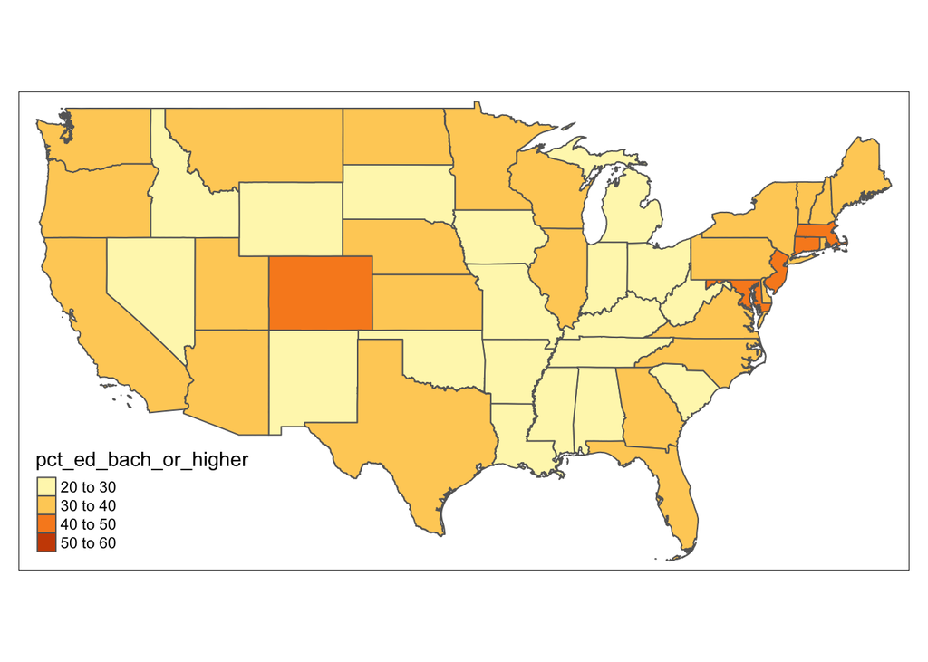

```r
#make sure to use the new filtered data set for the map
tm_shape(NEW_pctdata_new_clean_allstates_wide) +
  #use "pct_ed_bach_or_higher" so the package knows which value to shade by and "GEOID" so the map is pulling from the right state information
  tm_polygons("pct_ed_bach_or_higher", id = "GEOID")
```

– END —